# Version Control with Git

# Agenda

1. Setting Up Git
2. Creating a Repository
3. Tracking Changes
4. Exploring History
5. Ignoring Things
6. Remotes in GitHub
7. Collaborating
8. Conflicts
9. Open Science
10. Licensing
11. Citation
12. Hosting
13. Supplemental: Using Git from RStudio

# Automated Version Control

## Objectives

- Understand the benefits of an automated version control system.
- Understand the basics of how automated version control systems work.

## Questions

- What is version control and why should I use it?

[figure not shown]

### Paper Writing

- Imagine you drafted an excellent paragraph for a paper you are writing, but later ruin it. How would you retrieve the *excellent* version of your conclusion? Is it even possible?
- Imagine you have 5 co-authors. How would you manage the changes and comments they make to your paper? If you use LibreOffice Writer or Microsoft Word, what happens if you accept changes made using the `Track Changes` option? Do you have a history of those changes?

# Setting Up Git

## Objectives

- Configure `git` the first time it is used on a computer.
- Understand the meaning of the `--global` configuration flag.

## Questions

- How do I get set up to use Git?

# Creating a Repository

## Objectives

- Create a local Git repository.
- Describe the purpose of the `.git` directory.

## Questions

- Where does Git store information?

### Places to Create Git Repositories

Along with tracking information about recipes (the project we have already created), Alfredo would also like to track information about desserts specifically. Alfredo creates a `desserts` project inside his `recipes` project with the following sequence of commands:

```bash
$ cd ~/Desktop    # return to Desktop directory
$ cd recipes      # go into recipes directory, which is already a Git repository
$ ls -a           # ensure the .git subdirectory is still present in the recipes directory
$ mkdir desserts # make a sub-directory recipes/desserts
$ cd desserts    # go into desserts subdirectory
$ git init        # make the desserts subdirectory a Git repository
$ ls -a           # ensure the .git subdirectory is present indicating we have created a new Git repository
```

Is the `git init` command, run inside the `desserts` subdirectory, required for tracking files stored in the `desserts` subdirectory?

## Correcting `git init` Mistakes

Jimmy explains to Alfredo how a nested repository is redundant and may cause confusion down the road. Alfredo would like to go back to a single git repository. How can Alfredo undo his last `git init` in the `desserts` subdirectory?

# Tracking Changes

## Objectives

- Go through the modify-add-commit cycle for one or more files.
- Explain where information is stored at each stage of that cycle.
- Distinguish between descriptive and non-descriptive commit messages.

## Questions

- How do I record changes in Git?
- How do I check the status of my version control repository?
- How do I record notes about what changes I made and why?

[figure not shown]

### Choosing a Commit Message

Which of the following commit messages would be most appropriate for the last commit made to `guacamole.md`?

1. “Changes”
2. “Changed lemon for lime”
3. “Guacamole modified to the traditional recipe”

### Committing Changes to Git

Which command(s) below would save the changes of `myfile.txt` to my local Git repository?

1. ```bash
   $ git commit -m "my recent changes"
   ```

2. ```bash
   $ git init myfile.txt
   $ git commit -m "my recent changes"
   ```

3. ```bash
   $ git add myfile.txt
   $ git commit -m "my recent changes"
   ```

4. ```bash
   $ git commit -m myfile.txt "my recent changes"
   ```

### Committing Multiple Files

The staging area can hold changes from any number of files that you want to commit as a single snapshot.

1. Add some text to `guacamole.md` noting the rough price of the ingredients.
2. Create a new file `groceries.md` with a list of products and their prices for different markets.
3. Add changes from both files to the staging area, and commit those changes.

### `bio` Repository

- Create a new Git repository on your computer called `bio`.
- Write a three-line biography for yourself in a file called `me.txt`, commit your changes
- Modify one line, add a fourth line
- Display the differences between its updated state and its original state.

# Exploring History

## Objectives

- Explain what the HEAD of a repository is and how to use it.
- Identify and use Git commit numbers.
- Compare various versions of tracked files.
- Restore old versions of files.

## Questions

- How can I identify old versions of files?
- How do I review my changes?
- How can I recover old versions of files?

[figure not shown]

### Recovering Older Versions of a File

Jennifer has made changes to the Python script that she has been working on for weeks, and the modifications she made this morning “broke” the script and it no longer runs. She has spent ~ 1hr trying to fix it, with no luck…

Luckily, she has been keeping track of her project’s versions using Git! Which commands below will let her recover the last committed version of her Python script called `data_cruncher.py`?

1. `$ git restore`
2. `$ git restore data_cruncher.py`
3. `$ git restore -s HEAD~1 data_cruncher.py`
4. `$ git restore -s <unique ID of last commit> data_cruncher.py`
5. Both 2 and 4

### Reverting a Commit

Jennifer is collaborating with colleagues on her Python script. She realizes her last commit to the project’s repository contained an error, and wants to undo it. Jennifer wants to undo correctly so everyone in the project’s repository gets the correct change. The command `git revert [erroneous commit ID]` will create a new commit that reverses the erroneous commit.

The command `git revert` is different from `git restore -s [commit ID] .` because `git restore` returns the files not yet committed within the local repository to a previous state, whereas `git revert` reverses changes committed to the local and project repositories.

Below are the right steps and explanations for Jennifer to use `git revert`, what is the missing command?

1. `________ # Look at the git history of the project to find the commit ID`
2. Copy the ID (the first few characters of the ID, e.g. 0b1d055).
3. `git revert [commit ID]`
4. Type in the new commit message.
5. Save and close.

### Understanding Workflow and History

What is the output of the last command in

```bash
$ cd recipes
$ echo "I like tomatoes, therefore I like ketchup" > ketchup.md
$ git add ketchup.md
$ echo "ketchup enhances pasta dishes" >> ketchup.md
$ git commit -m "My opinions about the red sauce"
$ git restore ketchup.md
$ cat ketchup.md # this will print the content of ketchup.md on screen
```

1. ```
   ketchup enhances pasta dishes
   ```

2. ```
   I like tomatoes, therefore I like ketchup
   ```

3. ```
   I like tomatoes, therefore I like ketchup
   ketchup enhances pasta dishes
   ```

4. ```
   Error because you have changed ketchup.md without committing the changes
   ```

### Checking Understanding of `git diff`

Consider this command: `git diff HEAD~9 guacamole.md`. What do you predict this command will do if you execute it? What happens when you do execute it? Why?

Try another command, `git diff [ID] guacamole.md`, where *I**D* is replaced with the unique identifier for your most recent commit. What do you think will happen, and what does happen?

### Getting Rid of Staged Changes

`git restore` can be used to restore a previous commit when unstaged changes have been made, but will it also work for changes that have been staged but not committed? Make a change to `guacamole.md`, add that change using `git add`, then use `git restore` to see if you can remove your change.

### Explore and Summarize Histories

Exploring history is an important part of Git, and often it is a challenge to find the right commit ID, especially if the commit is from several months ago.

Imagine the `recipes` project has more than 50 files. You would like to find a commit that modifies some specific text in `guacamole.md`. When you type `git log`, a very long list appeared. How can you narrow down the search?

Recall that the `git diff` command allows us to explore one specific file, e.g., `git diff guacamole.md`. We can apply a similar idea here.

```bash
$ git log guacamole.md
```

Unfortunately some of these commit messages are very ambiguous, e.g., `update files`. How can you search through these files?

Both `git diff` and `git log` are very useful and they summarize a different part of the history for you. Is it possible to combine both? Let’s try the following:

```bash
$ git log --patch guacamole.md
```

You should get a long list of output, and you should be able to see both commit messages and the difference between each commit.

Question: What does the following command do?

```bash
$ git log --patch HEAD~9 *.md
```

# Ignoring Things

## Objectives

- Configure Git to ignore specific files.
- Explain why ignoring files can be useful.

## Questions

- How can I tell Git to ignore files I don’t want to track?

### Ignoring Nested Files

Given a directory structure that looks like:

```bash
pictures/cake
pictures/pizza
```

How would you ignore only `pictures/cake` and not `pictures/pizza`?

### Including Specific Files

How would you ignore all `.png` files in your root directory except for `final.png`? Hint: Find out what `!` (the exclamation point operator) does

### Ignoring Nested Files: Variation

Given a directory structure that looks similar to the earlier Nested Files exercise, but with a slightly different directory structure:

```bash
pictures/cake
pictures/pizza
pictures/pie
pictures/brownie
```

How would you ignore all of the contents in the pictures folder, but not `pictures/pie`?

Hint: think a bit about how you created an exception with the `!` operator before.

### Ignoring all data Files in a Directory

Assuming you have an empty .gitignore file, and given a directory structure that looks like:

```bash
pictures/data/location/gps/a.dat
pictures/data/location/gps/b.dat
pictures/data/location/gps/c.dat
pictures/data/location/gps/info.txt
pictures/plots
```

What’s the shortest `.gitignore` rule you could write to ignore all `.dat` files in `pictures/data/location/gps`? Do not ignore the `info.txt`.

### Ignoring all data Files in the repository

Let us assume you have many `.csv` files in different subdirectories of your repository. For example, you might have:

```bash
results/a.csv
data/experiment_1/b.csv
data/experiment_2/c.csv
data/experiment_2/variation_1/d.csv
```

How do you ignore all the `.csv` files, without explicitly listing the names of the corresponding folders?

### The Order of Rules

Given a `.gitignore` file with the following contents:

```bash
*.csv
!*.csv
```

What will be the result?

### Log Files

You wrote a script that creates many intermediate log-files of the form `log_01`, `log_02`, `log_03`, etc. You want to keep them but you do not want to track them through `git`.

1. Write **one** `.gitignore` entry that excludes files of the form `log_01`, `log_02`, etc.
2. Test your “ignore pattern” by creating some dummy files of the form `log_01`, etc.
3. You find that the file `log_01` is very important after all, add it to the tracked files without changing the `.gitignore` again.
4. Discuss with your neighbor what other types of files could reside in your directory that you do not want to track and thus would exclude via `.gitignore`.

# Remotes in GitHub

## Objectives

- Explain what remote repositories are and why they are useful.
- Push to or pull from a remote repository.

## Questions

- How do I share my changes with others on the web?

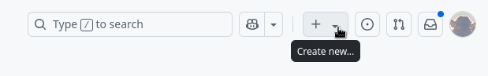

[figure not shown]

[figure not shown]

[figure not shown]

[figure not shown]

[figure not shown]

[figure not shown]

### GitHub GUI

Browse to your `recipes` repository on GitHub. Under the Code tab, find and click on the text that says “XX commits” (where “XX” is some number). Hover over, and click on, the three buttons to the right of each commit. What information can you gather/explore from these buttons? How would you get that same information in the shell?

### GitHub Timestamp

Create a remote repository on GitHub. Push the contents of your local repository to the remote. Make changes to your local repository and push these changes. Go to the repo you just created on GitHub and check the timestamps of the files. How does GitHub record times, and why?

### Push vs. Commit

In this episode, we introduced the “git push” command. How is “git push” different from “git commit”?

### GitHub License and README files

In this episode we learned about creating a remote repository on GitHub, but when you initialized your GitHub repo, you didn’t add a README.md or a license file. If you had, what do you think would have happened when you tried to link your local and remote repositories?

# Collaborating

## Objectives

- Clone a remote repository.
- Collaborate by pushing to a common repository.
- Describe the basic collaborative workflow.

## Questions

- How can I use version control to collaborate with other people?

[figure not shown]

[figure not shown]

### Switch Roles and Repeat

Switch roles and repeat the whole process.

### Review Changes

The Owner pushed commits to the repository without giving any information to the Collaborator. How can the Collaborator find out what has changed with command line? And on GitHub?

### Comment Changes in GitHub

The Collaborator has some questions about one line change made by the Owner and has some suggestions to propose.

With GitHub, it is possible to comment on the diff of a commit. Over the line of code to comment, a blue comment icon appears to open a comment window.

The Collaborator posts her comments and suggestions using the GitHub interface.

### Version History, Backup, and Version Control

Some backup software can keep a history of the versions of your files. They also allows you to recover specific versions. How is this functionality different from version control? What are some of the benefits of using version control, Git and GitHub?

# Conflicts

## Objectives

- Explain what conflicts are and when they can occur.
- Resolve conflicts resulting from a merge.

## Questions

- What do I do when my changes conflict with someone else’s?

[figure not shown]

### Solving Conflicts that You Create

Clone the repository created by your instructor. Add a new file to it, and modify an existing file (your instructor will tell you which one). When asked by your instructor, pull her changes from the repository to create a conflict, then resolve it.

### Conflicts on Non-textual files

What does Git do when there is a conflict in an image or some other non-textual file that is stored in version control?

### A Typical Work Session

You sit down at your computer to work on a shared project that is tracked in a remote Git repository. During your work session, you take the following actions, but not in this order:

- *Make changes* by appending the number `100` to a text file `numbers.txt`
- *Update remote* repository to match the local repository
- *Celebrate* your success with some fancy beverage(s)
- *Update local* repository to match the remote repository
- *Stage changes* to be committed
- *Commit changes* to the local repository

In what order should you perform these actions to minimize the chances of conflicts? Put the commands above in order in the *action* column of the table below. When you have the order right, see if you can write the corresponding commands in the *command* column. A few steps are populated to get you started.

| order | action . . . . . . . . . . | command . . . . . . . . . . |
| --- | --- | --- |
| 1 |  |  |
| 2 |  | `echo 100 >> numbers.txt` |
| 3 |  |  |
| 4 |  |  |
| 5 |  |  |
| 6 | Celebrate! |  |

# Open Science

## Objectives

- Explain how a version control system can be leveraged as an electronic lab notebook for computational work.

## Questions

- How can version control help me make my work more open?

### How Reproducible Is My Work?

Ask one of your labmates to reproduce a result you recently obtained using only what they can find in your papers or on the web. Try to do the same for one of their results, then try to do it for a result from a lab you work with.

### How to Find an Appropriate Data Repository?

Surf the internet for a couple of minutes and check out the generalist data repositories mentioned above: [Figshare](https://figshare.com/), [Zenodo](https://zenodo.org), [Dryad](https://datadryad.org/). Try to also find one or more repositories for data in your field. You might also find useful [these data repositories recommended by Nature](https://www.nature.com/sdata/data-policies/repositories). Discuss with your neighbor which data repository you might want to approach for your current project and explain why.

Confused by the sheer number of different repositories you could choose for your data? This [repository selection flowchart](https://zenodo.org/records/11105430) aims to “guide users through a series of considerations for slecting the right repository for sharing data.”

### How to Track Large Data or Image Files using Git?

Large data or image files such as `.md5` or `.psd` file types can be tracked within a github repository using the [Git Large File Storage](https://git-lfs.github.com) open source extension tool. This tool automatically uploads large file contents to a remote server and replaces the file with a text pointer within the github repository.

Try downloading and installing the Git Large File Storage extension tool, then add tracking of a large file to your github repository. Ask a colleague to clone your repository and describe what they see when they access that large file.

# Licensing

## Objectives

- Explain why adding licensing information to a repository is important.
- Choose a proper license.
- Explain differences in licensing and social expectations.

## Questions

- What licensing information should I include with my work?

### Can I Use Open License?

Find out whether you are allowed to apply an open license to your software. Can you do this unilaterally, or do you need permission from someone in your institution? If so, who?

### What licenses have I already accepted?

Many of the software tools we use on a daily basis (including in this workshop) are released as open-source software. Pick a project on GitHub from the list below, or one of your own choosing. Find its license (usually in a file called `LICENSE` or `COPYING`) and talk about how it restricts your use of the software. Is it one of the licenses discussed in this session? How is it different?

- [Git](https://github.com/git/git), the source-code management tool
- [CPython](https://github.com/python/cpython), the standard implementation of the Python language
- [Jupyter](https://github.com/jupyter), the project behind the web-based Python notebooks we’ll be using
- [EtherPad](https://github.com/ether/etherpad-lite), a real-time collaborative editor

# Citation

## Objectives

- Make your work easy to cite

## Questions

- How can I make my work easier to cite?

# Hosting

## Objectives

- Explain different options for hosting scientific work.

## Questions

- Where should I host my version control repositories?

### Can My Work Be Public?

Find out whether you are allowed to host your work openly in a public repository. Can you do this unilaterally, or do you need permission from someone in your institution? If so, who?

### Where Can I Share My Work?

Does your institution have a repository or repositories that you can use to share your papers, data and software? How do institutional repositories differ from services like [arXiV](https://arxiv.org/), [figshare](https://figshare.com/), [GitHub](https://github.com/) or [GitLab](https://about.gitlab.com/)?

# Supplemental: Using Git from RStudio

## Objectives

- Understand how to use Git from RStudio.

## Questions

- How can I use Git with RStudio?

[figure not shown]

[figure not shown]

[figure not shown]

[figure not shown]

[figure not shown]

[figure not shown]

[figure not shown]

[figure not shown]

[figure not shown]

[figure not shown]

### Challenge

1. Create a new directory within your project called `graphs`.
2. Modify the `.gitignore` so that the `graphs` directory is not version controlled.